# Anya Conti 2866125

Anya Conti

January 26, 2017

1. First, the standard exponential distribution (rate of 1) is used as follows.

```r
exp.draws.1 = rexp(200)
```

```r
mean(exp.draws.1)
sd(exp.draws.1)
```

[output not shown]

exp.draws.1 is a vector with values represented as 200 random draws from an exponential distribution with a rate of 1. Then the mean of those values is found to be 1.1451258, and then the standard deviation is found to be 1.0721469.

2. The above process is then repeated with exponential distributions with rates of 0.1, 0.5, 5, and 10.

```r
exp.draws.0.1 = rexp(200,0.1)
```

```r
mean(exp.draws.0.1)
sd(exp.draws.0.1)
```

[output not shown]

exp.draws.0.1 is a vector with values represented as 200 random draws from an exponential distribution with a rate of 0.1. Its mean is 11.6339704 and its standard deviation is 12.2107987.

```r
exp.draws.0.5 = rexp(200,0.5)
mean(exp.draws.0.5)
```

```
## [1] 1.766844
```

```r
sd(exp.draws.0.5)
```

```
## [1] 1.727801
```

exp.draws.0.5 is a vector with values represented as 200 random draws from an exponential distribution with a rate of 0.5. Its mean is 1.7668443 and its standard deviation is 1.7278009.

```r
exp.draws.5 = rexp(200,5)
mean(exp.draws.5)
```

```
## [1] 0.2251545
```

```r
sd(exp.draws.5)
```

```
## [1] 0.2132807
```

exp.draws.5 is a vector with values represented as 200 random draws from an exponential distribution with a rate of 5. Its mean is 0.2251545 and its standard deviation is 0.2132807.

```r
exp.draws.10 = rexp(200,10)
mean(exp.draws.10)
```

```
## [1] 0.1038687
```

```r
sd(exp.draws.10)
```

```
## [1] 0.112214
```

exp.draws.10 is a vector with values represented as 200 random draws from an exponential distribution with a rate of 10. Its mean is 0.1038687 and its standard deviation is 0.112214.

1. A histogram of the 200 draws from the standard exponential distribution was created, using the values from exp.draws.1. It shows how many points fall into each interval, or the distribution of the sample, and looks approximately the shape of the standard exponential distribution which they are pulled from so it is accurate.

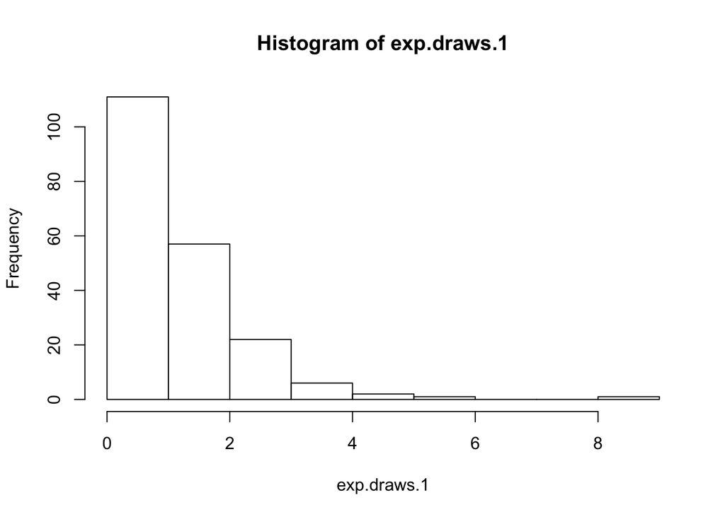

```r
hist(exp.draws.1)
```

2. The points of the 200 draws from the standard exponential distribution (the values from exp.draws.1) were then plotted according to when they they drawn. There does not appear to be a clear pattern, which means the draws were indeed random, and not dependent on time.

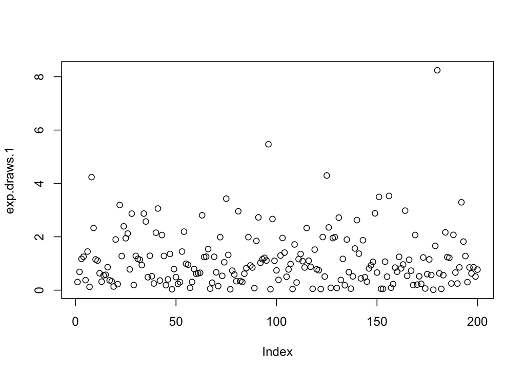

```r
plot(exp.draws.1)
```

3. Then the values of two of the other vectors of stored values drawn from an exponential distribution were plotted against each other. In this case, rates of 0.1 (exp.draws.0.1) and 10 (exp.draws.10) were chosen. There does not appear to be a pattern between the points, as expected.

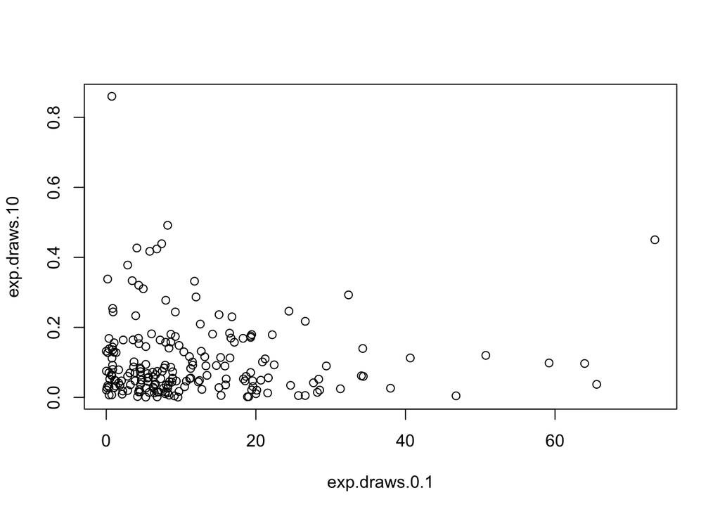

```r
plot(exp.draws.0.1,exp.draws.10)
```

4. First 3 vectors were created, one of the rates of each of the exponential distribution vectors, one of the means of each, and one of the standard deviations of each, in the order they were created: exp.draws.1, exp.draws.0.1, exp.draws.0.5, exp.draws.5, exp.draws.10.

```r
rates = c(1,0.1,0.5,5,10)
means = c(mean(exp.draws.1),mean(exp.draws.0.1),mean(exp.draws.0.5),mean(exp.draws.5),mean(exp.draws.10))
stdevs = c(sd(exp.draws.1),sd(exp.draws.0.1),sd(exp.draws.0.5),sd(exp.draws.5),sd(exp.draws.10))
```

1. The means of each were then plotted against the rates. The relationship almost looks like the first is equal to 1 over the other. (i.e. y=(1/x))

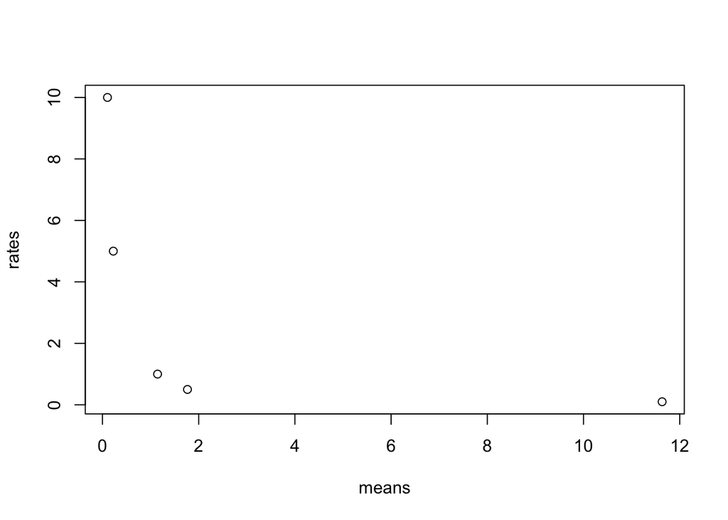

```r
plot(means,rates)
```

2. The standard deviations of each were then plotted against the rates. They have a similar relationship to each other as rates and means in that it appears the first is equal to 1 over the other. (i.e. y=(1/x))

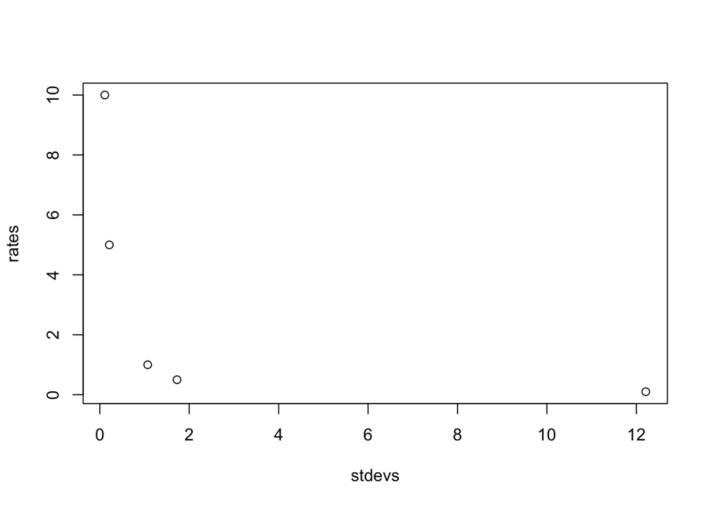

```r
plot(stdevs,rates)
```

3. The means of each were then plotted against the standard deviations. They appear to have a positive linear relationship: as one increases, the other increases and vice versa.

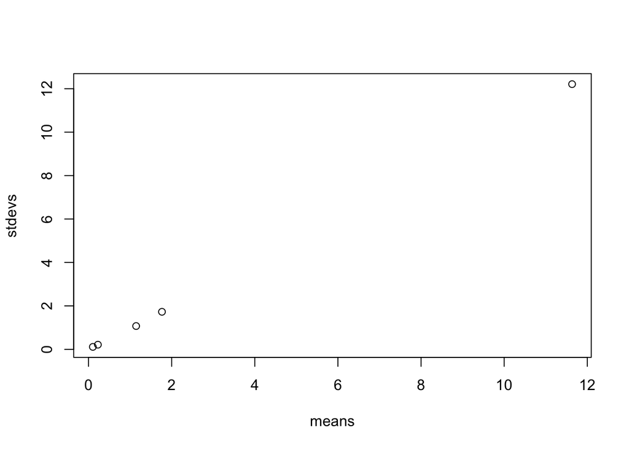

```r
plot(means,stdevs)
```